# Boston_House_with_SciKit_and_TensorFlow

Last update: 21.07.2018

## Motivation

At some point I have realized that most of my time I spend with Deep Neural Networks models, Reinforcement Learning framework and recently with classification problems using Random Forest. I would like to work with the above even more. I am constantly learning that. I like it. But it is not like a Nike store: "Just do it" does not work - time is the limit :) And than other topics waiting. I would like to go deeper into Deep Neural Network and RL, focus more on Autoencoders as well and more. Ehhh.... I need to focus on something. And relax. And this note is an effect of urgent need to relax but still working with what I like to - Machine Learning and doing my own study.

I have decided to take a step back and look at famous Boston House data set used for training and evaluation of Linear Regression model. But why not doing something more than just replicate that simple state ofthe art example?

I want to create Linear Model (LM) using SciKit Learn package and TensorFlow. Using SciKit LM I will look how number of traing/test samples affect evaluation error. And using TensorFlow I want to check how data prerprocessing is important for training the model when gradient descent optimization algorithm is used. I will use Tenorboard as a great tool for Deep Neural Network inspection.

## Main takeaway message

Using Boston House data set this note demonstrates importance of data scaling when training Tensorflow based Neural Network.

If preprocessing of the data is not used when traning TensorFlow model, it might cause model unable to train as weights are exploding. It can be detected for example by error message reporitng infinity values of weights and loss value. When using Tensorboard such a situation can lead to NaN error while creating histogram.

Therefore preprocessing of input data (e.g. standardization) is very important step in building the model. With Boston House data set skipping preprocessing does not allow to create a model.

## Content

*Boston Housing data set*

First I will present what is Boston Housing data set in general. I will show basic statistcs of the data and transform it into a shape and type convienient for further use. It will be fast jump in into the data set.

*SciKit Linear Regression model*

I will used SciKit LM model for training and evaluation. Samples are split into trainig and test category. It is interesting how samples number ratio of training to test samples affect performance of the model in term of MSE error.

*TesnorFlow Linear Regression model*

I will use TensorFlow to create a simple model. Than I can compare it with model I got when using SciKit. The comparison is made visually (plotting predictions) and by MSE value. It is a kind of validation of my Tensorflow model. Tensorflow model here is trained with data preprocessing applied.

*Visualization with Tensorboard*

Here I work with Tensorflow model I have created so far. I use Tensorboard to visualize how parameters of the model change over training epochs. Next I remove data prerprocessing and show how it impacts trainig model.

## Why using gradient descent optimization (TensorFlow) if closed-form solution exists (SciKit)

SciKit offers very easy to use way of training Linar Model. So I take the advantage of it to check what model I can get when Boston data set is used. SciKit LM model serves here as a quick jump in into a topic.

So why bother with TensorFlow when SciKit LM is available? There are two reasons:

1. The first one is because I want to quickly check something I am interested in: how preprocessing of data affect training used with gradient descent optimization algoritm. For that I will use TensorBoard.
2. The second reason is more of importance: when your data has many many features it is faster to use gradient descent optimization algorimth rather than closed-form eqation. I have preapared already fundamentals of gradient descent algoroithm [here](https://dkolmas.github.io/blog/2017/11/09/Foundation-of-backpropagation).  
   SciKit learn Linear Regression model is a part of [Generalized Linear Models](http://scikit-learn.org/stable/modules/linear_model.html). For Linear Model parameter estimation it uses closed-form solution:  
   $\beta=(X^TX+I\lambda)^{-1}X^TY$  
   With growing number of features simple linear model in SciKit becomes computationally inefficient comparing to gradient descent optimization algorithm. However there are many other optimization algorithms in SciKit that are mentioned in [this](https://datascience.stackexchange.com/questions/24907/what-optimization-algorithms-are-used-in-scikit-learn?answertab=votes#tab-top) post.

Becasue I use very small data set with small number of features only the first reason (data preprocessing impact on optimization outcome) is important to me now. And TensorFlow with Tensorboard suits here perfectly.

## What is the main take-away from that note

I want to present importance of data preprocessing when using gradient descent optimzation algorithm. That's it.

## Boston Housing data set

For this note I have decided to get familiar with famous [**Boston house-price data set**](http://lib.stat.cmu.edu/datasets/boston). I will use Boston data set for short. It is a small data set and I have not used it in the past. So there are two good reasons of using it. I could also dive into MNIST that I am familiar with. But the complexity of data can blur main purpose of that post. I want to keep it simple.

Boston data set can be directly accessed from [scikit-learn package](http://scikit-learn.org/stable/modules/generated/sklearn.datasets.load_boston.html)

Boston Housing data set is can be accessed from SciKit package. It is very convienient and as simple as shown below. Note that boston.data below refers to 13 features. It does not contain cloumn with name MEDV which you can find in the oryginal Boston data set collectively.

```python
from sklearn.datasets import load_boston
boston = load_boston()
print("Shape of the data (no MEDV included): ",boston.data.shape)
```

```
Shape of the data (no MEDV included):  (506, 13)
```

Column MEDV (Median value of owner-occupied homes in $1000's) is stored in the boston.target

```python
print("Shape of labels (orygnally under MEDV name): ", boston.target.shape)
```

```
Shape of labels (orygnally under MEDV name):  (506,)
```

Let's have a quick look on features names.

```python
print("Features names: ", [name for name in boston.feature_names[:]])
```

```
Features names:  ['CRIM', 'ZN', 'INDUS', 'CHAS', 'NOX', 'RM', 'AGE', 'DIS', 'RAD', 'TAX', 'PTRATIO', 'B', 'LSTAT']
```

Variables in order:

- CRIM per capita crime rate by town
- ZN proportion of residential land zoned for lots over 25,000 sq.ft.
- INDUS proportion of non-retail business acres per town
- CHAS Charles River dummy variable (= 1 if tract bounds river; 0 otherwise)
- NOX nitric oxides concentration (parts per 10 million)
- RM average number of rooms per dwelling
- AGE proportion of owner-occupied units built prior to 1940
- DIS weighted distances to five Boston employment centres
- RAD index of accessibility to radial highways
- TAX full-value property-tax rate per 10,000 dollars
- PTRATIO pupil-teacher ratio by town
- B 1000(Bk - 0.63)^2 where Bk is the proportion of blacks by town
- LSTAT % lower status of the population
- MEDV Median value of owner-occupied homes in $1000'

Because I am interested in impact of preprocessing on optimization algorithm I want to check mean and standard deviation. Also I would like to see min and max value. Everything for each features separately.

```python
import numpy as np
import matplotlib.pyplot as plt
import pandas as pd
```

```python
# Calculate min and max value for each feature
MeanVar = list()
for k in range(boston.data.shape[1]):
    ft = boston.data[:,k]
    MeanVar.append(( np.mean(ft), np.std(ft)))
MeanVar = np.asarray(MeanVar)
```

```python
# Calculate min and max value for each feature
MinMax = list()
for k in range(boston.data.shape[1]):
    ft = boston.data[:,k]
    MinMax.append(( np.min(ft), np.max(ft)))
MinMax = np.asarray(MinMax)
```

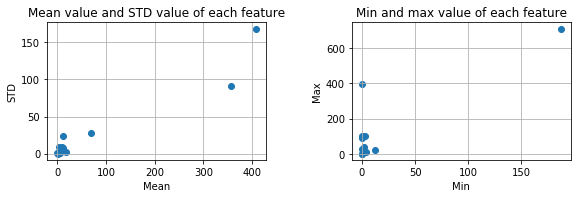

```python
fig, (ax1, ax2) = plt.subplots(nrows=1, ncols=2, figsize=(8,2.5))
plt.tight_layout(w_pad=5.5)
ax1.scatter(MeanVar[:,0],MeanVar[:,1],)
ax1.grid()
ax1.set_title('Mean value and STD value of each feature')
ax1.set_xlabel('Mean')
ax1.set_ylabel('STD')

ax2.scatter(MinMax[:,0],MinMax[:,1])
ax2.grid()
ax2.set_title('Min and max value of each feature')
ax2.set_xlabel('Min')
ax2.set_ylabel('Max')
```

Haa, there are two features that stands out! Actually at that moment I am not iterested in which features they are. It is important to me the fact that there are two features that are statistically different from all the other features. What happens if I use it for training the way it is (w/o preprocessing)? I will use TensorFlow/Tensorboard for that investigation.

Now I need to do some preparation of the data for the sake of comfort of using it later.

```python
# Transform dictionary type into data frame, prserve columns names
BostonDf = pd.DataFrame((boston.data), columns = boston.feature_names)

# Adding the target into a BostonDf so eveything is kept together
BostonDf['MEDV'] = boston.target
```

What is inside:

```python
# After moving data into data frames...
print(BostonDf.head())
```

```
      CRIM    ZN  INDUS  CHAS    NOX     RM   AGE     DIS  RAD    TAX  \
0  0.00632  18.0   2.31   0.0  0.538  6.575  65.2  4.0900  1.0  296.0
1  0.02731   0.0   7.07   0.0  0.469  6.421  78.9  4.9671  2.0  242.0
2  0.02729   0.0   7.07   0.0  0.469  7.185  61.1  4.9671  2.0  242.0
3  0.03237   0.0   2.18   0.0  0.458  6.998  45.8  6.0622  3.0  222.0
4  0.06905   0.0   2.18   0.0  0.458  7.147  54.2  6.0622  3.0  222.0

   PTRATIO       B  LSTAT  MEDV
0     15.3  396.90   4.98  24.0
1     17.8  396.90   9.14  21.6
2     17.8  392.83   4.03  34.7
3     18.7  394.63   2.94  33.4
4     18.7  396.90   5.33  36.2
```

I will split data into state of the art namings: X and Y

```python
X = BostonDf.drop('MEDV', axis = 1)
Y = BostonDf['MEDV']
```

With X and Y (pandas data frames) I can go further now.

## SciKit Linear Regression model

First lets import packages that are necessary for Linear Regression with SciKit and other packages. TesnorFlow is also imported here so to make it everything at once.

```python
import sklearn
from sklearn.linear_model import LinearRegression
from sklearn.model_selection import train_test_split

import tensorflow as tf
%matplotlib inline
```

```python
print("SciKit Learn version: ",sklearn.__version__)
print("TensorFlow version:   ",tf.__version__)
```

```
SciKit Learn version:  0.19.1
TensorFlow version:    1.8.0
```

Divide data into training and testing part...  
and I am choosing now arbitraly ratio of training samples to be 75% of all samples. I set also seed (random_state) so to be able reproduce exact results when running the same code multiple times.

```python
X_train, X_test, Y_train, Y_test = train_test_split(X, Y, test_size = 0.25, random_state = 100)
print("Number of training samples: ",X_train.shape[0])
print("Number of test samples:     ",X_test.shape[0])
```

```
Number of training samples:  379
Number of test samples:      127
```

The code below is all what I need to train the model and use it for prediction with test samples.

```python
# Define a model
LinReg_SciKit = LinearRegression()
# Train the model
LinReg_SciKit.fit(X_train, Y_train)
# Use it for prediction
Y_pred = LinReg_SciKit.predict(X_test)
```

Access to calculated coefficients is possible through: LinReg*SciKit.coef* and LinReg*SciKit.intercept*

Using test samples and predicted values now we can see how far plotted dots goes far away from a line. The perferc prediction means all the dots cover a line with a slope of 45 degrees. As shown on the figure it is not the case. MSE error is 27.2 which is quite large (comparing to absolute value of prediction). And the worst happens for highest price (value of 50).  
In general, I will use this results as a refernece for my further analysis.

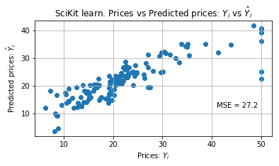

```python
plt.figure(figsize=(6,3))
plt.grid()
plt.scatter(Y_test, Y_pred)
plt.xlabel("Prices: $Y_i$")
plt.ylabel("Predicted prices: $\hat{Y}_i$")
plt.title("SciKit learn. Prices vs Predicted prices: $Y_i$ vs $\hat{Y}_i$")
mse = sklearn.metrics.mean_squared_error(Y_test, Y_pred)
s = 'MSE = ' + str(np.round(mse,1))
plt.text(41,12, s)
```

Now let's do a Linear Regression model training for different size of training samples (and testing samples). It will allow to answer a question of what number of traing samples could be a better choice.

```python
LinReg_SciKit_multi = LinearRegression()
TestSamplesRatio = [0.05, 0.1, 0.15, 0.2, 0.25, 0.3, 0.35, 0.4]
Mse = list()
for theTestSize in TestSamplesRatio:
    X_train, X_test, Y_train, Y_test = train_test_split(X, Y, test_size = theTestSize, random_state = 100)
    LinReg_SciKit_multi.fit(X_train, Y_train)
    Y_pred = LinReg_SciKit.predict(X_test)
    Mse.extend( [sklearn.metrics.mean_squared_error(Y_test, Y_pred)] )
```

```python
theBestRatio = TestSamplesRatio[ Mse.index(np.min(Mse)) ]
print("The best ratio of test samples to training samples is: ", theBestRatio)
print("Ratio {0} corresponds to {1} training samples and {2} test samples".format(theBestRatio, \
       np.round((1-theBestRatio)*X.shape[0]), np.round(theBestRatio*X.shape[0])))
```

```
The best ratio of test samples to training samples is:  0.15
Ratio 0.15 corresponds to 430.0 training samples and 76.0 test samples
```

## TesnorFlow Linear Regression model

In this part I use TensorFlow to create and train a linear model. Main focuse here is the check how data preprocessing affects result of training. First I am going to perform data preprocessing. And later on I will use oryginal data without preprocessing.

As for the preprocessing I choose to use standardization as it can help me in case of outlier happens in the data set. Using Min-Max preprocessing an outlier could destroy scaling of the feature (push most of the values into "corner" - very little value range) and make training difficult.  
Without feature scaling (here: standardization) the gradinet descen algorithm would require more time to get the same result.

```python
def feature_standardization(dataset):
    mu = np.mean(dataset,axis=0)
    sigma = np.std(dataset,axis=0)
    return (dataset - mu)/sigma
```

```python
# X, Y are already used above. X, Y are pandas Data Frames
n_dim = X.shape[1]
print("Number of inputs: ",n_dim)
```

```
Number of inputs:  13
```

Prepare placegolders for inputs and outputs

```python
# X, Y are already used above. X, Y are pandas Data Frames
X_tf = tf.placeholder(tf.float32, shape=[None, n_dim ], name='X')
Y_tf = tf.placeholder(tf.float32, shape=[ None, 1 ], name='Y')
```

Here I create parameters of the linear model. I have no prioir knowledge how to initialize them so to minimize MSE error so I arbitrally used initialization as seen below.

```python
W = tf.Variable(tf.ones([n_dim,1]), name="weights", dtype=tf.float32)
b = tf.Variable(0.0, name="bias")
```

Linear model definition comes below

```python
# Define an operation X*W + b
Xw = tf.matmul(X_tf, W)
Y_tf_pred = tf.add(Xw,b)
```

I define MSE loss function and use simple gradient descent optimization algorithm (instead of AdamOptimizer I would go normally for).

```python
# Define loss function for gradient descent optimization algorithm
learning_rate = 0.01
loss = tf.reduce_mean(tf.square(Y_tf - Y_tf_pred))
optimizer = tf.train.GradientDescentOptimizer(learning_rate)
training_op = optimizer.minimize(loss)
init = tf.global_variables_initializer()
```

Data transformation from data frames into numpy arrays. I change data type from float64 into float32.

```python
# Chanage data frame into numpy array
X_ar = np.asarray(X, dtype=np.float32)
Y_ar = np.asarray(Y, dtype=np.float32)
Y_ar = np.reshape(Y_ar, [-1,1])
print(X_ar.shape)
print(Y_ar.shape)
```

```
(506, 13)
(506, 1)
```

Here the data preprocessing comes in

```python
X_ar_strd = feature_standardization(X_ar)
```

And here is the traning part. I use 200 epochs (before I have tried with 1000 but it was definitelly to much) and learning rate 0.01 (defined above).  
Another parameters is number of samples for training. Here I made use of knowledge from using SciKit learn. Above I discoevered that 85% of all samples is a good choice for number of training samples.  
I also set a seed her in order to make possible to reproduce the same results as I run it multimple times.

```python
training_epochs = 200
sess = tf.Session()
sess.run(init)

np.random.seed(100)
rnd_indices = np.random.rand(X_ar_strd.shape[0]) < 0.85
train_x = X_ar_strd[rnd_indices]
train_y = Y_ar[rnd_indices]
test_x = X_ar_strd[~rnd_indices]
test_y = Y_ar[~rnd_indices]
loss_change = list()

for epoch in range(training_epochs):
    #sess.run(training_op,feed_dict={X_tf:train_x, Y_tf:train_y})

    loss_value,_ = sess.run( [loss, training_op], feed_dict={X_tf: train_x, Y_tf: train_y})
    loss_change.extend([ loss_value ])


wcoeff, bias = sess.run([W, b])
sess.close()
```

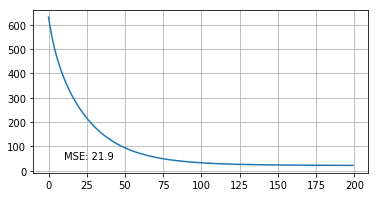

```python
plt.figure(figsize=(6,3))
plt.grid()
plt.plot(loss_change)
s = 'MSE: ' + str(np.round(loss_change[-1],1))
plt.text(10,50,s)
```

200 epochs was enough to get stable MSE.

Let's do the prediction using trained model

```python
Prediction_values = np.dot(test_x,wcoeff) + bias
```

And visualization part showing how far we are from a line (ideally all dots should be placed on line with 45 degrees slope)

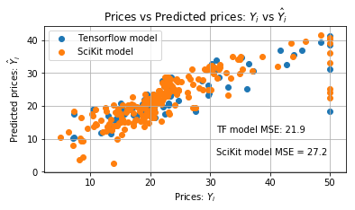

```python
plt.figure(figsize=(6,3))
plt.grid()
plt.scatter(test_y, Prediction_values)
plt.scatter(Y_test, Y_pred)
plt.xlabel("Prices: $Y_i$")
plt.ylabel("Predicted prices: $\hat{Y}_i$")
plt.title("Prices vs Predicted prices: $Y_i$ vs $\hat{Y}_i$")
plt.legend(['Tensorflow model','SciKit model'])
s = 'TF model MSE: ' + str(np.round(loss_change[-1],1))
plt.text(31,12, s)
s = 'SciKit model MSE = ' + str(np.round(mse,1))
plt.text(31,5, s)
```

## Visualization with TensorBoard

```python
from datetime import datetime   # As the code can be run many time, each time
                                # a new log file for TensorBoard is created in a separate
                                # directory named with current date and time
from os.path import join        # use join function when creating paths
```

```python
LOGDIR_ROOT = '/home/damian/GitRepositories/DataPreprocessing/log_02'
```

```python
# X, Y are already used above. X, Y are pandas Data Frames
n_dim = X.shape[1]
print("Number of inputs: ",n_dim)
```

```
Number of inputs:  13
```

```python
tf.reset_default_graph()  # To avoid many duplicated nodes in the default grpah
sess = tf.Session()
```

Prepare placegolders for inputs and outputs

```python
# X, Y are already used above. X, Y are pandas Data Frames
# define placeholder for inputs to network
with tf.name_scope('Data'):
    X_tf = tf.placeholder(tf.float32, shape=[None, n_dim ], name='X')
    Y_tf = tf.placeholder(tf.float32, shape=[ None, 1 ], name='Y')
```

```python
W = tf.Variable(tf.zeros([n_dim,1]), name="weights", dtype=tf.float32)
b = tf.Variable(0.0, name="bias")
tf.summary.histogram("W_h", W)
tf.summary.histogram("b_h", b)
tf.summary.scalar("b_val",b)
```

```
<tf.Tensor 'b_val:0' shape=() dtype=string>
```

Linear model definition comes below

```python
# Define an operation X*W + b. NOTE: there is no activation functoin (or the activation function is linear)
# NN model building
with tf.name_scope('Linear_Model'):
    Y_pred = tf.matmul(X_tf, W) + b
```

```python
# Define loss function for gradient descent optimization algorithm
learning_rate = 0.01
# The error between prediciton and real data
with tf.name_scope('loss'):
    loss = tf.reduce_mean(tf.square(Y_tf - Y_pred))
    tf.summary.scalar("Loss",loss)
# The training optimization method
with tf.name_scope('train'):
    optimizer = tf.train.GradientDescentOptimizer(learning_rate)
    training_op = optimizer.minimize(loss)
with tf.name_scope('In_Out_Delta'):
    io_delta = tf.reduce_mean(tf.abs(Y_tf - Y_pred))
    tf.summary.scalar("InOutDelta",io_delta)

init = tf.global_variables_initializer()
```

```python
# Chanage data frame into numpy array
X_ar = np.asarray(X, dtype=np.float32)
Y_ar = np.asarray(Y, dtype=np.float32)
Y_ar = np.reshape(Y_ar, [-1,1])
print(X_ar.shape)
print(Y_ar.shape)
```

```
(506, 13)
(506, 1)
```

Here the data preprocessing comes in

```python
X_ar_strd = feature_standardization(X_ar)
```

```python
now = datetime.utcnow().strftime("%Y%m%d%H%M")
LOGDIR = join(LOGDIR_ROOT,now)   # Create a log directory with date and time stamp
                                 # Note that time is given with resoulution of minutes
print("Log data is stored in: ",LOGDIR)

training_epochs = 200
sess.run(init)

np.random.seed(100)
rnd_indices = np.random.rand(X_ar_strd.shape[0]) < 0.85
train_x = X_ar_strd[rnd_indices]
train_y = Y_ar[rnd_indices]
test_x = X_ar_strd[~rnd_indices]
test_y = Y_ar[~rnd_indices]
loss_change = list()

summ = tf.summary.merge_all()
writer = tf.summary.FileWriter(LOGDIR, sess.graph)

for epoch in range(training_epochs):

    # For tensorflow visualisation
    if epoch % 5 == 0:
        s = sess.run(summ, feed_dict={X_tf: train_x, Y_tf: train_y})
        writer.add_summary(s, epoch)

    # Training
    loss_value,_ = sess.run( [loss, training_op], feed_dict={X_tf: train_x, Y_tf: train_y})

wcoeff, bias = sess.run([W, b])
sess.close()
```

```
Log data is stored in:  /home/damian/GitRepositories/DataPreprocessing/log_02/201807220613
```

Here is the example how to run tensorboard:  
tensorboard --logdir=/home/damian/GitReposities/DataPreprocessing/log_02

```python
tf.get_collection(tf.GraphKeys.GLOBAL_VARIABLES)
```

```
[<tf.Variable 'weights:0' shape=(13, 1) dtype=float32_ref>,
 <tf.Variable 'bias:0' shape=() dtype=float32_ref>]
```

This is how the graps looks like

[figure not shown]

I am getting to the point. I want to show weights and bias during the trainig. For the values shown below data preprocessing was used.  
First lets have a look on bias value change over time.

[figure not shown]

TensorFlow offers visualisation using [histogram](https://www.tensorflow.org/guide/tensorboard_histograms). Below I show a figure of bias histogram. The value at the back are oldest (at the beggining of trainig) and value with index of 170 is the last one recorder. Tensorboard has its own way of creating histogram and it may create some artifacts. However, for visualisation purpose this histogram is very enough. And when compared with the figure above it is claear how bias changed over training epochs.

[figure not shown]

Now let's visualize weights. Have a look first for a second on final values of weights that were captured after training.

```python
print("Final weigths values: ")
print(wcoeff)
```

```
Final weigths values:
[[-0.4695255 ]
 [ 0.6861485 ]
 [-0.5618586 ]
 [ 0.69608533]
 [-0.75010073]
 [ 2.9449759 ]
 [-0.28158   ]
 [-2.0191853 ]
 [ 0.6494186 ]
 [-0.6057047 ]
 [-1.9416535 ]
 [ 0.8413766 ]
 [-2.9971044 ]]
```

Knowing the values presented above it is easier to interpret the histogram of weights shown below. On x axis we can see distribution of weights at a given (y axis) epoch. All the weights were intialize with zeros which can be seen on the hostogram at the back side of the figure. As the training progresses weights are taking diferent values and histogram show these changes nicely.

[figure not shown]

If we look at the final recorded epoch (y axis = 170) we can see a certain histogram of weights. We can compare and contrast it with manally stored weights. Let's focuse on the range of weights betwee -1 and 0.

```python
[ np.round(w,2) for w in wcoeff if (w>-1.0 and w<0.0)]
```

```
[array([-0.47], dtype=float32),
 array([-0.56], dtype=float32),
 array([-0.75], dtype=float32),
 array([-0.28], dtype=float32),
 array([-0.61], dtype=float32)]
```

There are 5 values in that range and it makes a bin of the histogram accordingly larger (higher).

Next, I will continou showing how lack of preprocessing affects training. I will use the same model and graph define above but input data I will leave as they are.

```python
from math import isnan
```

```python
tf.reset_default_graph()  # To avoid many duplicated nodes in the default grpah
sess = tf.Session()
```

Prepare placegolders for inputs and outputs

```python
# X, Y are already used above. X, Y are pandas Data Frames
# define placeholder for inputs to network
with tf.name_scope('Data'):
    X_tf = tf.placeholder(tf.float32, shape=[None, n_dim ], name='X')
    Y_tf = tf.placeholder(tf.float32, shape=[ None, 1 ], name='Y')
```

```python
W = tf.Variable(tf.zeros([n_dim,1]), name="weights", dtype=tf.float32)
b = tf.Variable(0.0, name="bias")
tf.summary.histogram("W_h_np", W)
b_2 = tf.where(tf.is_nan(b), -70., b)
tf.summary.histogram("b_h_np", b_2)
tf.summary.scalar("b_val_np",b_2)
```

```
<tf.Tensor 'b_val_np:0' shape=() dtype=string>
```

Linear model definition comes below

```python
# Define an operation X*W + b. NOTE: there is no activation functoin (or the activation function is linear)
# NN model building
with tf.name_scope('Linear_Model'):
    Y_pred = tf.matmul(X_tf, W) + b
```

```python
# Define loss function for gradient descent optimization algorithm
learning_rate = 0.0001
# The error between prediciton and real data
with tf.name_scope('loss'):
    loss = tf.reduce_mean(tf.square(Y_tf - Y_pred))
    tf.summary.scalar("Loss_np",loss)
# The training optimization method
with tf.name_scope('train'):
    optimizer = tf.train.GradientDescentOptimizer(learning_rate)
    training_op = optimizer.minimize(loss)
with tf.name_scope('In_Out_Delta'):
    io_delta = tf.reduce_mean(tf.abs(Y_tf - Y_pred))
    tf.summary.scalar("InOutDelta_np",io_delta)

init = tf.global_variables_initializer()
```

```python
# Chanage data frame into numpy array
X_ar = np.asarray(X, dtype=np.float32)
Y_ar = np.asarray(Y, dtype=np.float32)
Y_ar = np.reshape(Y_ar, [-1,1])
print(X_ar.shape)
print(Y_ar.shape)
```

```
(506, 13)
(506, 1)
```

Note ther is no preprocessing of input data

```python
#X_ar_strd = feature_standardization(X_ar)
X_ar_strd = X_ar
```

```python
now = datetime.utcnow().strftime("%Y%m%d%H%M")
LOGDIR = join(LOGDIR_ROOT,now)   # Create a log directory with date and time stamp
                                 # Note that time is given with resoulution of minutes
print("Log data is stored in: ",LOGDIR)

training_epochs = 200
sess.run(init)

np.random.seed(100)
rnd_indices = np.random.rand(X_ar_strd.shape[0]) < 0.85
train_x = X_ar_strd[rnd_indices]
train_y = Y_ar[rnd_indices]
test_x = X_ar_strd[~rnd_indices]
test_y = Y_ar[~rnd_indices]
loss_change = list()

summ = tf.summary.merge_all()
writer = tf.summary.FileWriter(LOGDIR, sess.graph)

for epoch in range(training_epochs):

    # Training
    loss_value,_ = sess.run( [loss, training_op], feed_dict={X_tf: train_x, Y_tf: train_y})
    print("Epoch: {0}, Loss: {1}".format(epoch,loss_value))
    #print("Is inf: ",tf.is_inf(loss_value))

    s = sess.run(summ, feed_dict={X_tf: train_x, Y_tf: train_y})
    writer.add_summary(s, epoch)

    if epoch==19:
        break

wcoeff, bias = sess.run([W, b])
sess.close()
```

```
Log data is stored in:  /home/damian/GitRepositories/DataPreprocessing/log_02/201807220613
Epoch: 0, Loss: 573.2123413085938
Epoch: 1, Loss: 1656188.5
Epoch: 2, Loss: 6218330112.0
Epoch: 3, Loss: 23359278546944.0
Epoch: 4, Loss: 8.77497209103319e+16
Epoch: 5, Loss: 3.296341489571982e+20
Epoch: 6, Loss: 1.2382790570067314e+24
Epoch: 7, Loss: 4.6516277941394994e+27
Epoch: 8, Loss: 1.7473960076734023e+31
Epoch: 9, Loss: 6.564139424933535e+34
Epoch: 10, Loss: inf
Epoch: 11, Loss: inf
Epoch: 12, Loss: inf
Epoch: 13, Loss: inf
Epoch: 14, Loss: inf
Epoch: 15, Loss: inf
Epoch: 16, Loss: inf
Epoch: 17, Loss: inf
Epoch: 18, Loss: inf
Epoch: 19, Loss: inf
```

When looking at loss over epochs it is clear how lack of input preprocessing affected the training process. Also weigths (shown bellow) confirm the chalange of training without proper data preprocessing.

```python
wcoeff
```

```
array([[-1.6734771e+32],
       [-3.6705762e+32],
       [-4.4375589e+32],
       [-2.4466696e+30],
       [-2.1047652e+31],
       [-2.2925661e+32],
       [-2.6358625e+33],
       [-1.3136754e+32],
       [-4.0867476e+32],
       [-1.6222246e+34],
       [-6.8730176e+32],
       [-1.3099815e+34],
       [-4.9843795e+32]], dtype=float32)
```

I checked the histogram and it is not very informative. Therefore I think it is much better to look into weigths and loss values only.